# Using hierarchical clustering to remove multicollinearity

```python
import pandas as pd
import numpy as np
import json
import seaborn as sns
import collections
from scipy.cluster import hierarchy
from scipy.spatial import distance

sns.set(style="white", rc={"figure.figsize": (11.7, 8.27)})
```

## Loading data

```python
df = pd.read_pickle("../data/data_renamed.pkl").drop(["x85", "x94"], axis=1) # x85 has >99% nulls and x94 is constant
df
```

|  | x00 | x01 | x02 | x03 | x04 | x05 | x06 | x07 | x08 | x09 | ... | x84 | x86 | x87 | x88 | x89 | x90 | x91 | x92 | x93 | x95 |
| --- | --- | --- | --- | --- | --- | --- | --- | --- | --- | --- | --- | --- | --- | --- | --- | --- | --- | --- | --- | --- | --- |
| 0 | 1 | 0.370594 | 0.424389 | 0.405750 | 0.601457 | 0.601457 | 0.998969 | 0.796887 | 0.808809 | 0.302646 | ... | 0.118250 | 0.716845 | 0.009219 | 0.622879 | 0.601453 | 0.827890 | 0.290202 | 0.026601 | 0.564050 | 0.016469 |
| 1 | 1 | 0.464291 | 0.538214 | 0.516730 | 0.610235 | 0.610235 | 0.998946 | 0.797380 | 0.809301 | 0.303556 | ... | 0.047775 | 0.795297 | 0.008323 | 0.623652 | 0.610237 | 0.839969 | 0.283846 | 0.264577 | 0.570175 | 0.020794 |
| 2 | 1 | 0.426071 | 0.499019 | 0.472295 | 0.601450 | 0.601364 | 0.998857 | 0.796403 | 0.808388 | 0.302035 | ... | 0.025346 | 0.774670 | 0.040003 | 0.623841 | 0.601449 | 0.836774 | 0.290189 | 0.026555 | 0.563706 | 0.016474 |
| 3 | 1 | 0.399844 | 0.451265 | 0.457733 | 0.583541 | 0.583541 | 0.998700 | 0.796967 | 0.808966 | 0.303350 | ... | 0.067250 | 0.739555 | 0.003252 | 0.622929 | 0.583538 | 0.834697 | 0.281721 | 0.026697 | 0.564663 | 0.023982 |
| 4 | 1 | 0.465022 | 0.538432 | 0.522298 | 0.598783 | 0.598783 | 0.998973 | 0.797366 | 0.809304 | 0.303475 | ... | 0.047725 | 0.795016 | 0.003878 | 0.623521 | 0.598782 | 0.839973 | 0.278514 | 0.024752 | 0.575617 | 0.035490 |
| ... | ... | ... | ... | ... | ... | ... | ... | ... | ... | ... | ... | ... | ... | ... | ... | ... | ... | ... | ... | ... | ... |
| 6814 | 0 | 0.493687 | 0.539468 | 0.543230 | 0.604455 | 0.604462 | 0.998992 | 0.797409 | 0.809331 | 0.303510 | ... | 0.027951 | 0.799927 | 0.000466 | 0.623620 | 0.604455 | 0.840359 | 0.279606 | 0.027064 | 0.566193 | 0.029890 |
| 6815 | 0 | 0.475162 | 0.538269 | 0.524172 | 0.598308 | 0.598308 | 0.998992 | 0.797414 | 0.809327 | 0.303520 | ... | 0.031470 | 0.799748 | 0.001959 | 0.623931 | 0.598306 | 0.840306 | 0.278132 | 0.027009 | 0.566018 | 0.038284 |
| 6816 | 0 | 0.472725 | 0.533744 | 0.520638 | 0.610444 | 0.610213 | 0.998984 | 0.797401 | 0.809317 | 0.303512 | ... | 0.007542 | 0.797778 | 0.002840 | 0.624156 | 0.610441 | 0.840138 | 0.275789 | 0.026791 | 0.565158 | 0.097649 |
| 6817 | 0 | 0.506264 | 0.559911 | 0.554045 | 0.607850 | 0.607850 | 0.999074 | 0.797500 | 0.809399 | 0.303498 | ... | 0.022916 | 0.811808 | 0.002837 | 0.623957 | 0.607846 | 0.841084 | 0.277547 | 0.026822 | 0.565302 | 0.044009 |
| 6818 | 0 | 0.493053 | 0.570105 | 0.549548 | 0.627409 | 0.627409 | 0.998080 | 0.801987 | 0.813800 | 0.313415 | ... | 0.005579 | 0.815956 | 0.000707 | 0.626680 | 0.627408 | 0.841019 | 0.275114 | 0.026793 | 0.565167 | 0.233902 |

6819 rows × 94 columns

## Computing correlation matrix

```python
corr = df.drop("x00", axis=1).corr("spearman")
corr.iloc[:5, :5]
```

|  | x01 | x02 | x03 | x04 | x05 |
| --- | --- | --- | --- | --- | --- |
| x01 | 1.000000 | 0.931685 | 0.989081 | 0.506232 | 0.504194 |
| x02 | 0.931685 | 1.000000 | 0.941016 | 0.496501 | 0.494273 |
| x03 | 0.989081 | 0.941016 | 1.000000 | 0.515740 | 0.513636 |
| x04 | 0.506232 | 0.496501 | 0.515740 | 1.000000 | 0.999055 |
| x05 | 0.504194 | 0.494273 | 0.513636 | 0.999055 | 1.000000 |

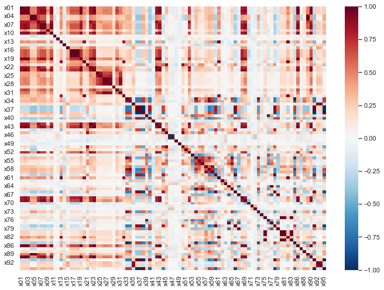

```python
_ = sns.heatmap(corr, cmap="RdBu_r")
```

## Distance matrix

Correlation by itself is not a distance metric because:

1. It can be negative
2. Similar variables (high correlation) should be closer (small distance)

To transform correlation into a distance, we simply use `1 - abs(corr)`. The absolute solves problem 1 and subtracting from 1 solves problem 2

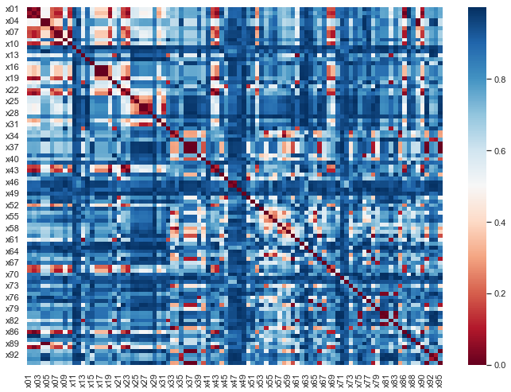

```python
distance_matrix = 1 - corr.abs()
_ = sns.heatmap(distance_matrix, cmap="RdBu")
```

```python
# Ensuring that the matrix is symmetric
distance_matrix.shape
```

```
(93, 93)
```

```python
# distance.squareform receives a symmetric matrix and returns a flat array of its upper triangular values
distance.squareform(distance_matrix)
```

```
array([0.06831538, 0.01091866, 0.49376796, ..., 0.08504273, 0.80536184,
       0.76513807])
```

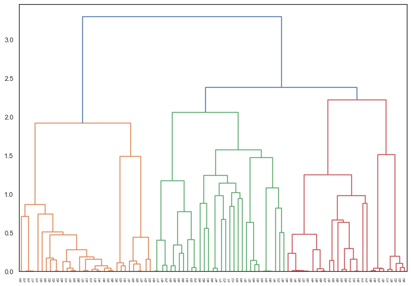

```python
_ = hierarchy.dendrogram(
    hierarchy.ward(distance.squareform(distance_matrix)),
    labels=corr.columns.to_list()
)
```

## Natural clusters

```python
def cluster_features_ward(dist_matrix, dist_threshold):
    dist_linkage = hierarchy.ward(distance.squareform(dist_matrix))
    cluster_ids = hierarchy.fcluster(dist_linkage, dist_threshold, criterion="distance")

    cluster_to_feature = collections.defaultdict(list)
    for feature_id, cluster_id in enumerate(cluster_ids):
        cluster_to_feature[cluster_id].append(dist_matrix.columns[feature_id])

    return cluster_to_feature
```

```python
natural_clustering = cluster_features_ward(distance_matrix, 2.3)
len(natural_clustering)
```

```
3
```

```python
pd.Series({k: len(v) for k, v in natural_clustering.items()}, name="features").sort_values(ascending=False)
```

```
1    32
2    32
3    29
Name: features, dtype: int64
```

```python
for cluster, features in natural_clustering.items():
    c = df[features].corr("spearman").abs()
    np.fill_diagonal(c.values, np.nan)
    print("Cluster", cluster)
    print("\tAverage absolute correlation", c.mean().mean().round(2))
    print("\tMinimum absolute correlation", c.min().min().round(2))
    print("\tMaximum absolute correlation", c.max().max().round(2))
    print("\tMedian absolute correlation ", c.median().median().round(2))
```

```
Cluster 1
	Average absolute correlation 0.54
	Minimum absolute correlation 0.06
	Maximum absolute correlation 1.0
	Median absolute correlation  0.68
Cluster 2
	Average absolute correlation 0.18
	Minimum absolute correlation 0.0
	Maximum absolute correlation 1.0
	Median absolute correlation  0.14
Cluster 3
	Average absolute correlation 0.41
	Minimum absolute correlation 0.01
	Maximum absolute correlation 1.0
	Median absolute correlation  0.46
```

We can see that the natural clusters are not a good choice here. We want to have as many features as we can, which means dealing with relatively high correlations. The natural clusters have a very high range of correlations inside them, which means we will have more than one non-collinear feature in each natural cluster.

## Picking a threshold

```python
# to store selected features
selected_features = []
```

```python
DISTANCE_THRESHOLD = 0.5
clustering = cluster_features_ward(distance_matrix, DISTANCE_THRESHOLD)
len(clustering)
```

```
33
```

```python
pd.Series({k: len(v) for k, v in clustering.items()}, name="features").sort_values(ascending=False)
```

```
3     17
26    10
7      6
33     5
28     5
32     4
8      4
9      4
23     3
6      3
10     3
21     3
1      3
14     2
24     2
```

[output cut: 19 more lines]

## Cluster 3: profitability measures

```python
def plot_cluster_corr_matrix(corr, cluster_map, cluster_id):
    cm = corr.loc[cluster_map[cluster_id], cluster_map[cluster_id]]
    sns.heatmap(cm, cmap="RdBu_r")
    print(f"Minimum absolute correlation: {cm.abs().min().min().round(2)}")
```

```
Minimum absolute correlation: 0.68
```

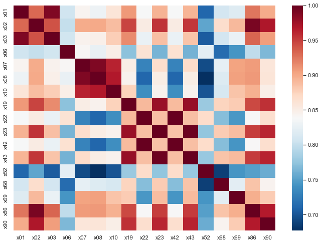

```python
plot_cluster_corr_matrix(corr, clustering, 3)
```

```python
def compute_corr_with_target(df, cluster_map, cluster_id):
    return (
        df[clustering[cluster_id]]
        .corrwith(df["x00"], method="spearman")
        .round(2)
        .sort_values(key=lambda x: abs(x), ascending=False)
    )
```

```python
compute_corr_with_target(df, clustering, 3)
```

```
x19   -0.24
x23   -0.23
x86   -0.23
x68   -0.23
x43   -0.23
x10   -0.23
x01   -0.22
x69   -0.22
x90   -0.22
x02   -0.22
x08   -0.22
x07   -0.22
x03   -0.22
x42   -0.19
x22   -0.19
x06   -0.18
x52   -0.17
dtype: float64
```

The most important feature is x19: Persistent EPS in the last four seasons. The sign makes sense: the higher a company's earnings per share (EPS), the higher its profitability and thus the lower its bankruptcy risk. Lets calculate the skewness of those features to get an idea of how badly behaved are their distribution.

```python
def compute_skew(df, cluster_map, cluster_id):
    return df[clustering[cluster_id]].skew().round(2).sort_values(key=lambda x: abs(x), ascending=False)
```

```python
compute_skew(df, clustering, 3)
```

```
x69    82.33
x06   -70.24
x10   -53.20
x08   -53.00
x07   -52.48
x90   -37.96
x68   -11.14
x42     8.95
x22     8.81
x52     7.79
x43     6.38
x23     6.00
x19     5.14
x86    -3.68
x02    -1.03
x03    -0.76
x01    -0.32
dtype: float64
```

```python
def plot_feature_hist(df, feature):
    df[feature].plot.hist(bins=50)
```

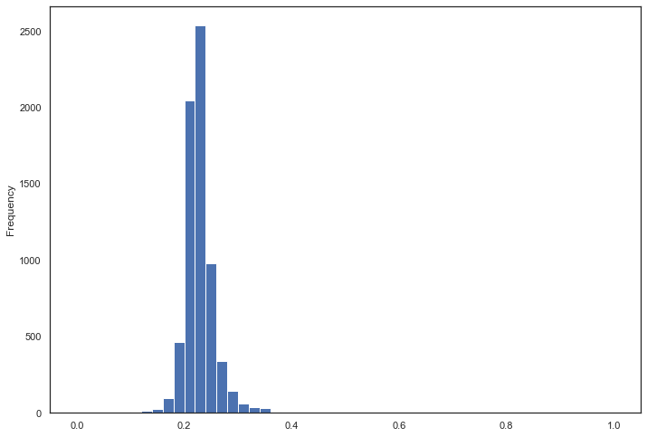

```python
plot_feature_hist(df, "x19")
```

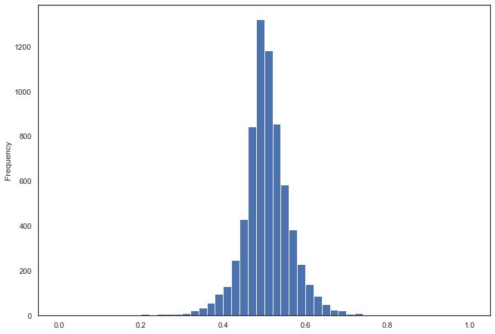

```python
plot_feature_hist(df, "x01")
```

x19 is not too bad compared to the most symmetric feature, x01 (return over assets - ROA). It will be easy to preprocess x19 to make it symmetric and it has 10% more correlation with the target. It also makes theoretical sense. It is thus a good choice for the group of profitability measures.

```python
selected_features.append("x19")
```

## Cluster 26: debt measures

```
Minimum absolute correlation: 0.44
```

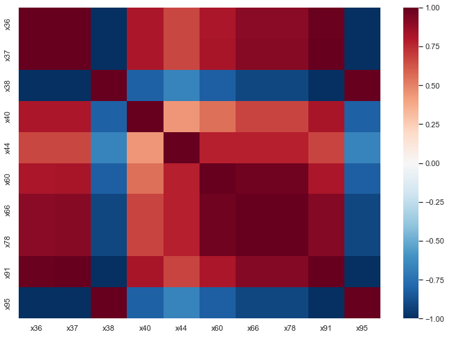

```python
plot_cluster_corr_matrix(corr, clustering, 26)
```

```python
compute_corr_with_target(df, clustering, 26)
```

```
x36    0.22
x37    0.22
x38   -0.22
x40    0.22
x95   -0.22
x91    0.20
x66    0.18
x78    0.18
x60    0.17
x44    0.09
dtype: float64
```

```python
compute_skew(df, clustering, 26)
```

```
x36    46.36
x91    27.46
x66    23.80
x78    23.80
x40    20.84
x44    13.11
x95     7.40
x60     1.61
x37     0.98
x38    -0.98
dtype: float64
```

```python
df["x36"].describe()
```

```
count    6.819000e+03
mean     4.416337e+06
std      1.684069e+08
min      0.000000e+00
25%      3.007049e-03
50%      5.546284e-03
75%      9.273293e-03
max      9.940000e+09
Name: x36, dtype: float64
```

The best feature here seems to be x36: total debt over total net worth. But its skewness is also the highest. It is pretty ugly, with an outlier of over a million, compared to the 3/4 of companies having total debt over total net worth just bellow 1%. x37 (debt ratio), however, is the second best feature and also has the second lowest skewness. It seems a much more well-behaved feature which is nearly as much predictive and reasonable.

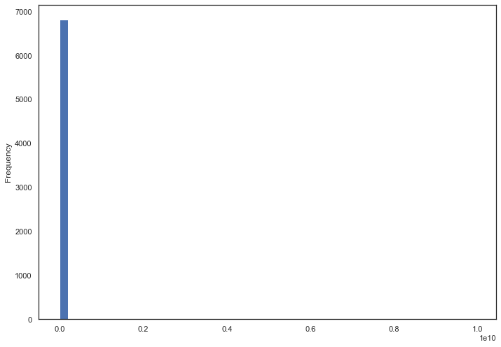

```python
plot_feature_hist(df, "x36")
```

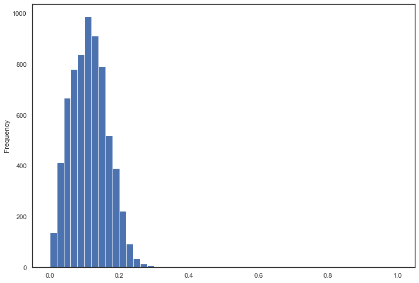

```python
plot_feature_hist(df, "x37")
```

```python
selected_features.append("x37")
```

## Cluster 7: growth measures

```
Minimum absolute correlation: 0.67
```

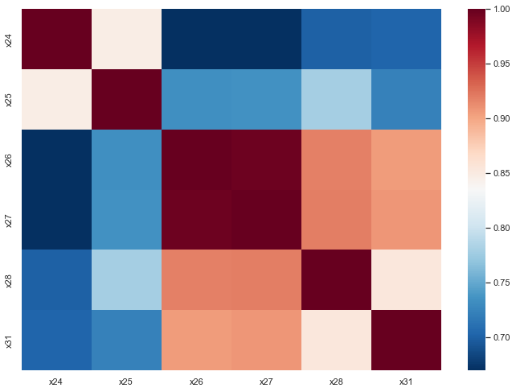

```python
plot_cluster_corr_matrix(corr, clustering, 7)
```

```python
compute_corr_with_target(df, clustering, 7)
```

```
x28   -0.13
x26   -0.12
x27   -0.12
x31   -0.11
x24   -0.09
x25   -0.09
dtype: float64
```

```python
compute_skew(df, clustering, 7)
```

```
x24    77.93
x25   -71.69
x28    67.10
x31    62.50
x26   -25.58
x27   -25.26
dtype: float64
```

The most important growth measure here is x28: continuous net profit growth rate. It makes total sense: the more the net profit of a company grows, the less chance it has of going bankrupt. Yet growth measures are very ill-behaved, which also makes sense: some companies (like startups) have abnormally high growth rates compared to other companies. This leads to long tails in distribution. It will be harder to preprocess the chosen growth measure. I will chose x26: after-tax net profit growth rate. It is just slightly less predictive (it has about 92% of x28's correlation with the target), but much less asymmetric (it has only about 38% of x28's skewness), making the trade-off worthwhile. It also is a much more intuitive measure that should make interpretation of predictions easier.

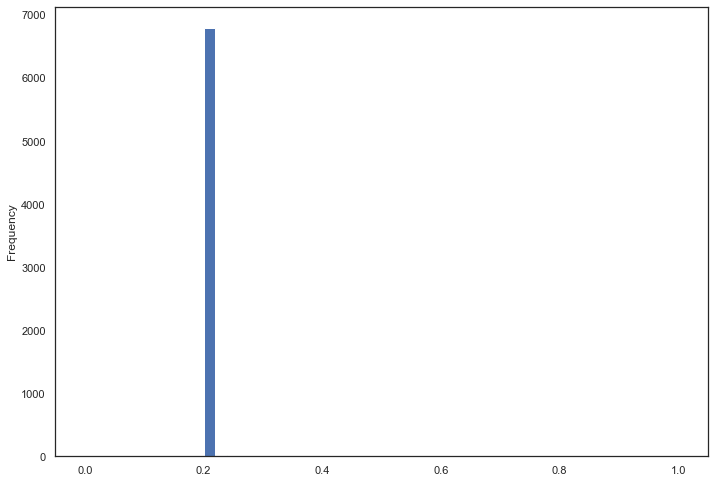

```python
plot_feature_hist(df, "x28")
```

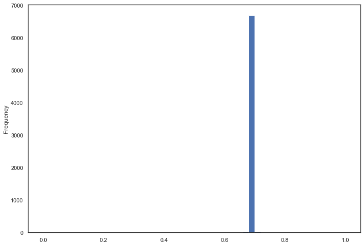

```python
plot_feature_hist(df, "x26")
```

```python
selected_features.append("x26")
```

## Cluster 33: operating funds measures

```
Minimum absolute correlation: 0.8
```

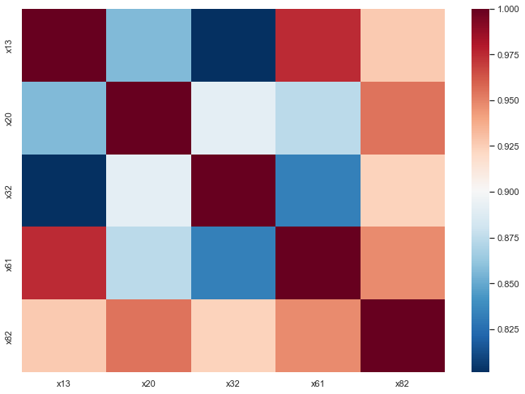

```python
plot_cluster_corr_matrix(corr, clustering, 33)
```

```python
compute_corr_with_target(df, clustering, 33)
```

```
x61   -0.15
x13   -0.14
x20   -0.13
x82   -0.13
x32   -0.09
dtype: float64
```

```python
compute_skew(df, clustering, 33)
```

```
x20    8.02
x13    3.99
x61    3.78
x32    2.32
x82   -0.44
dtype: float64
```

x61 (operating funds to liabilities) seems the best feature here. It is the most predictive and also seems to have a decent amount of symmetry.

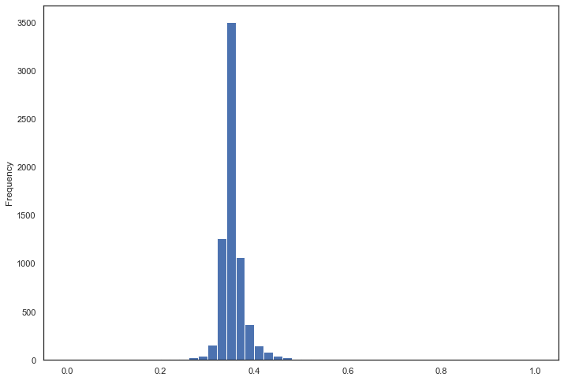

```python
plot_feature_hist(df, "x61")
```

```python
selected_features.append("x61")
```

## Cluster 28: liquidity measures

```
Minimum absolute correlation: 0.69
```

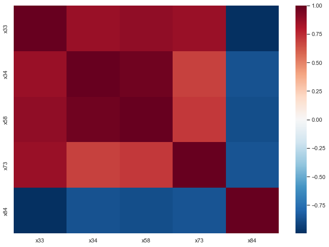

```python
plot_cluster_corr_matrix(corr, clustering, 28)
```

```python
compute_corr_with_target(df, clustering, 28)
```

```
x34   -0.20
x33   -0.19
x58   -0.19
x84    0.19
x73   -0.13
dtype: float64
```

```python
compute_skew(df, clustering, 28)
```

```
x33    82.58
x58    47.95
x34    31.64
x73   -28.58
x84    13.19
dtype: float64
```

x84 (current liabilities to current assets) seems the best feature here. It is just 1 percentage point less correlated with the target than the most correlated feature (x34, quick ratio), but the least asymmetric and therefore the easiest to preprocess. It is also more straightforward to interpret.

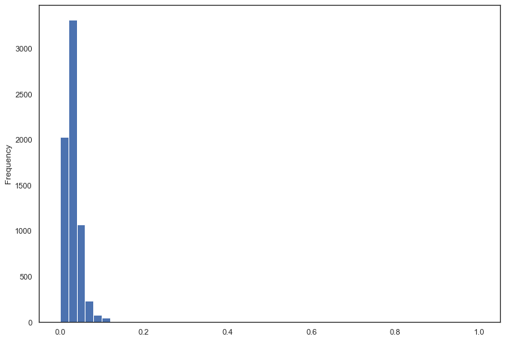

```python
plot_feature_hist(df, "x84")
```

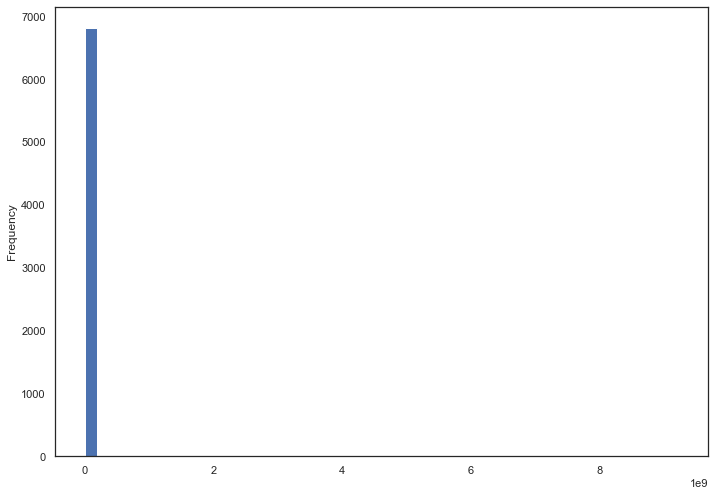

```python
plot_feature_hist(df, "x34")
```

```python
selected_features.append("x84")
```

## Cluster 32: cashflow measures

```
Minimum absolute correlation: 0.95
```

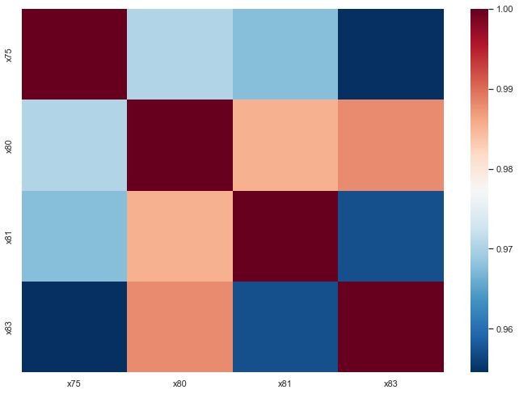

```python
plot_cluster_corr_matrix(corr, clustering, 32)
```

```python
compute_corr_with_target(df, clustering, 32)
```

```
x75   -0.09
x80   -0.09
x83   -0.09
x81   -0.08
dtype: float64
```

```python
compute_skew(df, clustering, 32)
```

```
x75   -47.87
x83    19.94
x81     1.01
x80    -0.23
dtype: float64
```

x80 (cashflow to total assets) is clearly the best feature here.

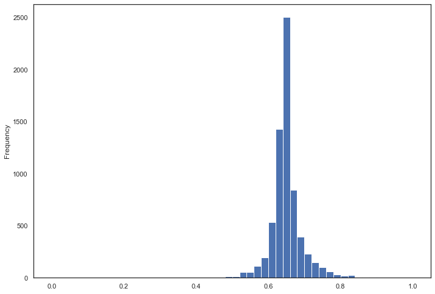

```python
plot_feature_hist(df, "x80")
```

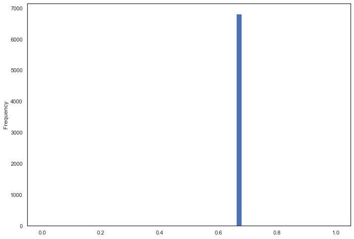

```python
plot_feature_hist(df, "x75")
```

```python
selected_features.append("x80")
```

## Cluster 8: long-term liabilities

```
Minimum absolute correlation: 0.71
```

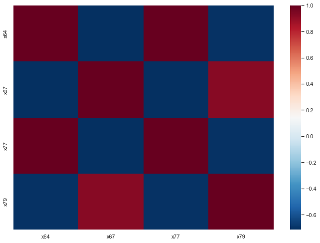

```python
plot_cluster_corr_matrix(corr, clustering, 8)
```

```python
compute_corr_with_target(df, clustering, 8)
```

```
x79    0.12
x67    0.09
x64   -0.03
x77   -0.03
dtype: float64
```

```python
compute_skew(df, clustering, 8)
```

```
x79    33.79
x67    12.40
x64    -0.84
x77    -0.84
dtype: float64
```

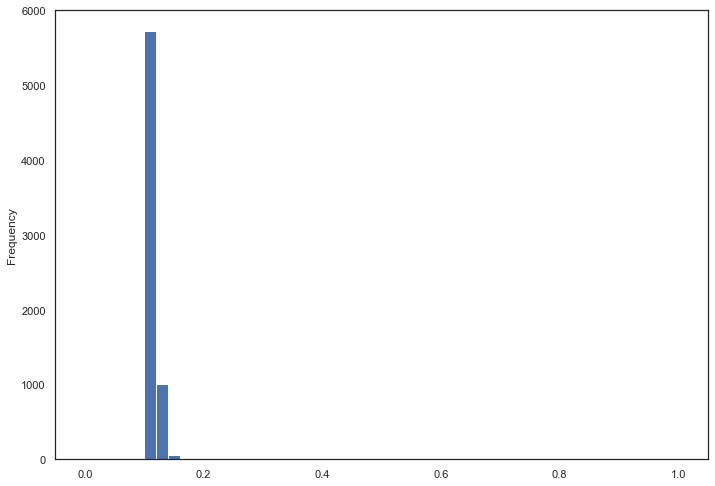

```python
plot_feature_hist(df, "x79")
```

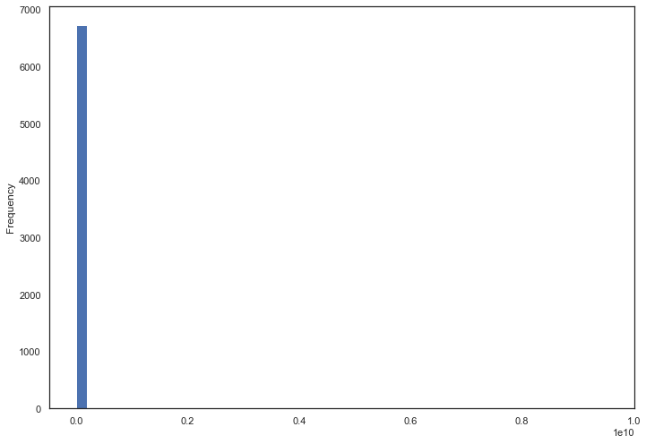

```python
plot_feature_hist(df, "x67")
```

x79 (equity to long-term liabilities) is the best feature here. It is interesting to note how the skewness measure was somewhat misleading here -- it was good to plot the histogram as a sanity check on the distributions.

```python
selected_features.append("x79")
```

## Cluster 9: working capital

```
Minimum absolute correlation: 0.66
```

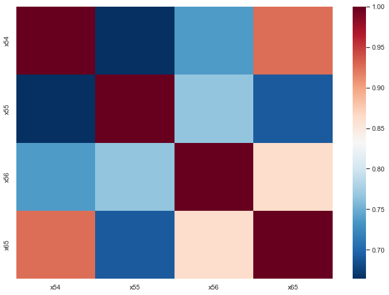

```python
plot_cluster_corr_matrix(corr, clustering, 9)
```

```python
compute_corr_with_target(df, clustering, 9)
```

```
x54   -0.17
x65   -0.12
x55   -0.09
x56   -0.04
dtype: float64
```

```python
compute_skew(df, clustering, 9)
```

```
x65   -36.20
x55     0.34
x54    -0.19
x56     0.08
dtype: float64
```

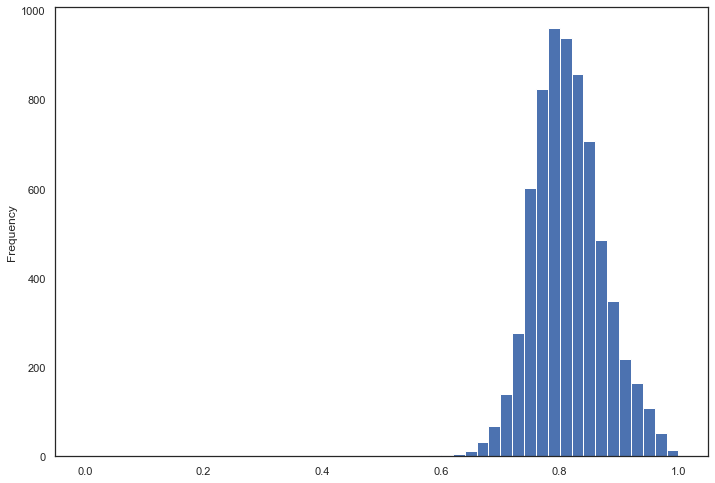

```python
plot_feature_hist(df, "x54")
```

```python
# x54 is working capital to total assets
selected_features.append("x54")
```

## Cluster 23: gross margin

```
Minimum absolute correlation: 1.0
```

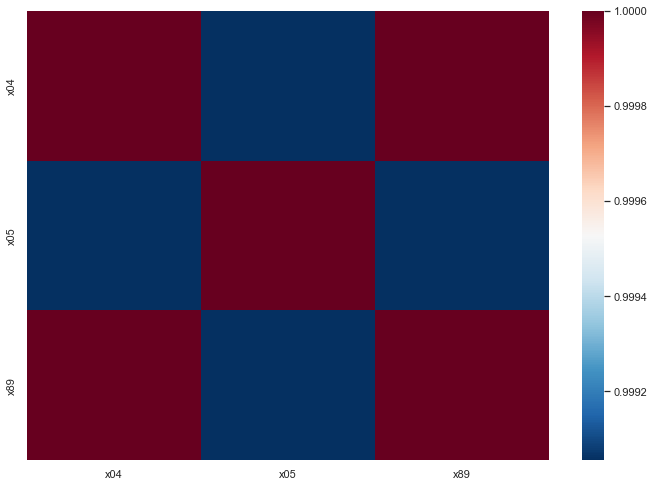

```python
plot_cluster_corr_matrix(corr, clustering, 23)
```

```python
compute_corr_with_target(df, clustering, 23)
```

```
x04   -0.15
x05   -0.15
x89   -0.15
dtype: float64
```

```python
compute_skew(df, clustering, 23)
```

```
x05   -8.07
x04   -8.04
x89   -8.04
dtype: float64
```

Features here seem all the same, so lets pick the one which is easier to interpret: x04 (operating gross margin).

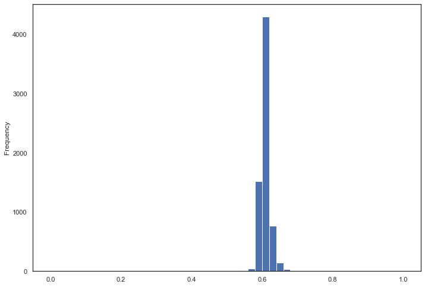

```python
plot_feature_hist(df, "x04")
```

```python
selected_features.append("x04")
```

## Cluster 6: interest costs

```
Minimum absolute correlation: 0.89
```

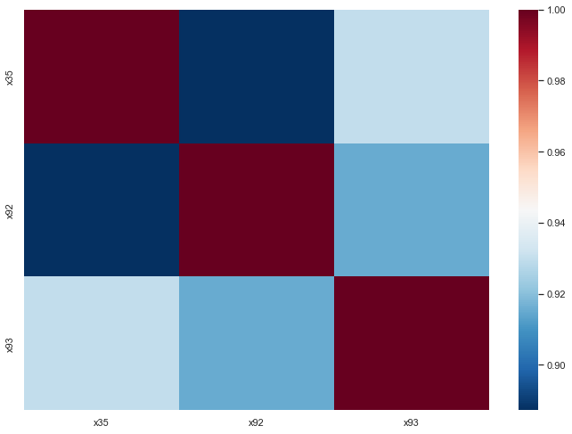

```python
plot_cluster_corr_matrix(corr, clustering, 6)
```

```python
compute_corr_with_target(df, clustering, 6)
```

```
x92   -0.15
x35   -0.13
x93   -0.13
dtype: float64
```

```python
compute_skew(df, clustering, 6)
```

```
x92    45.72
x35   -16.82
x93   -13.94
dtype: float64
```

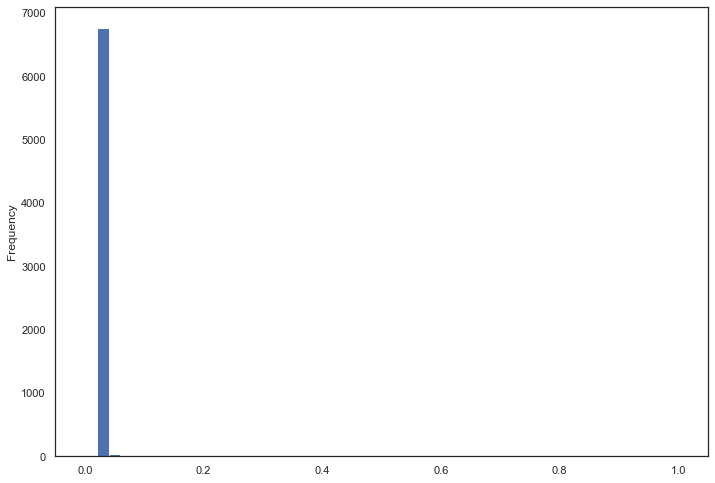

```python
plot_feature_hist(df, "x92")
```

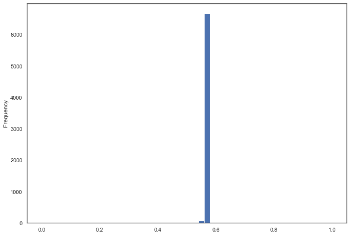

```python
plot_feature_hist(df, "x93")
```

x93 (interest coverage ratio) is the best feature here. The correlation-skewness trade-off also pays here: we get 86% of the highest correlation with the target in the cluster, but only about 30% the corresponding asymmetry. x93 is also very straightforward to understand.

```python
selected_features.append("x93")
```

## Cluster 10: investment measures

```
Minimum absolute correlation: 0.63
```

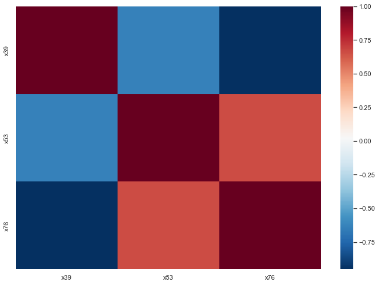

```python
plot_cluster_corr_matrix(corr, clustering, 10)
```

```python
compute_corr_with_target(df, clustering, 10)
```

```
x39   -0.12
x53    0.09
x76    0.06
dtype: float64
```

```python
compute_skew(df, clustering, 10)
```

```
x76    82.58
x53    27.48
x39    24.97
dtype: float64
```

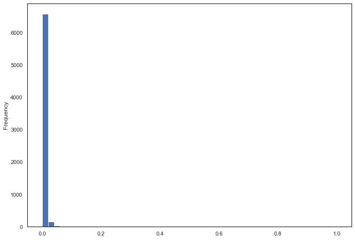

```python
plot_feature_hist(df, "x39")
```

```python
selected_features.append("x39")
```